[figure not shown]

# Data Analytics Manager

Data Exercise

Matthew Schuelke

2025-10-29

# Project Description

The St. Louis Metropolitan Police Department utilizes the National Incident Based Reporting System (NIBRS) to collect and track crime data. NIBRS captures details on each single crime incident—as well as on separate offenses within the same incident.

Explore the relationship between type of crime, neighborhoods, and seasons.

Review the topic and the publicly available data below. Use descriptive or exploratory statistics to demonstrate your review process. Build two (2) multivariate models exploring relationships within the topic. Please share code that you used to manipulate the data, create new variables, etc. when you submit the exercise results.

For the scheduled debrief: Prepare to explain the statistical models you used, why you selected them, and how you assessed model fit and assumptions. Describe your thought process, results and conclusions.

# Research

I first explored the police department website for information about the data and its generating process. I was interested in finding a data dictionary as well as any other available information. While I did not come across a dictionary, I did find the frequently asked question document as well as links to FBI pages with some additional information.

Some of my findings included:

1. Definitions for concepts like calls for service, incident reports and crime.
2. The retirement of UCR Summary Reporting (SRS) in favor of NIBRS and their relationship.
3. When and how data is supplemented and updated.
4. How victim number is unique within incident but not across for de-identification purposes.
5. What “unfounded” means for a given incident.

# Import NIBRS Data

```r
if(params$cache) {
  # read data as string
  nibrs_data_raw <- read_csv(
    "https://slmpd.org/wp-content/uploads/2024/03/2021-2023.csv",
    col_types = cols(.default = "c"),
    na = "NULL"
  )

  # save cache
  saveRDS(nibrs_data_raw, "nibrs_data_raw.rds")
}

# load cache
nibrs_data_raw <- readRDS("nibrs_data_raw.rds")
```

I imported the data as raw characters to avoid loosing any information due to implicit casting.

I then examined each column individually looking for anomalies and making sure I could cast each to an appropriate data type. I used regular expressions to identify patterns for validation purposes. I then used univariate statistics and visualizations such as histograms to get an understanding of each column. I also checked for missing data.

I did not include this code here because it is not very interesting.

Some highlights that I found included:

```r
nibrs_data_raw %>%
  transmute(IncidentDate = as_date(IncidentDate)) %>%
  count(IncidentDate < "2021-01-01") %>%
  mutate(p = 100 * round(n / sum(n), 4)) %>%
  gt()
```

| IncidentDate < "2021-01-01" | n | p |
| --- | --- | --- |
| FALSE | 179094 | 99.42 |
| TRUE | 1044 | 0.58 |

1,044 or a little more than a half percent of the data had incident dates prior to what I expected in the file.

```r
nibrs_data_raw %>%
  select(Neighborhood) %>%
  count(Neighborhood == "NA (Outside City)") %>%
  mutate(p = 100 * round(n / sum(n), 4)) %>%
  gt()
```

| Neighborhood == "NA (Outside City)" | n | p |
| --- | --- | --- |
| FALSE | 178792 | 99.25 |
| TRUE | 127 | 0.07 |
| NA | 1219 | 0.68 |

127 offenses were listed as having occurred outside the city.

1,219 or a bit more than half a percent of the offenses were not ascribed to a neighborhood.

My understanding of the data at this point is offense level data is nested within incidents and associated incident-level data which are nested within neighborhoods.

I keyed in on columns for:

1. incident date (for project time component - especially season)
2. incident number (model at the offense or incident level)
3. offense description (considered for the project type of crime component)
4. NIBRS class (considered for the project type of crime component)
5. offense classification (considered for the project type of crime component)
6. neighborhood (for the project neighborhood component)

# Models Under Consideration

1. Logistic regression
2. Poisson regression
3. Negative Binomial regression
4. Multinomial regression
5. AutoRegressive Integrated Moving Average (ARIMA)
6. Hierarchical/mixed model variants of the above

I choose to start with something simple and chose Poisson. I then thought it might be good to get some outside data in case I decided to use an offset to control for exposure.

# Import GIS Data

I decided to retrieve data from:

1. American Community Survey
2. Area Deprivation Index

```r
# read shape file
neighborhood_shapes <- sf::st_read("Neighborhoods/Neighborhoods.shp") %>%
  sf::st_transform(crs = 4326)
```

```r
# calculate neighborhood areas
neighborhood_shapes$area_km2 <- neighborhood_shapes %>%
  sf::st_area() %>%
  as.numeric() %>%
  { . / 1000^2 }

if(params$cache) {
  # get 2023 american community survey variables at the block group level via api
  acs_block_group <- tidycensus::get_acs(
    geography = "block group",
    variables = c(
      total_pop = "B01003_001",
      med_hh_income = "B19013_001"
    ),
    year = 2023,
    state = "MO",
    county = "St. Louis city",
    geometry = TRUE
  ) %>%
    sf::st_transform(sf::st_crs(neighborhood_shapes))

  # save cache
  saveRDS(acs_block_group, "acs_block_group.rds")
}

# load cache
acs_block_group <- readRDS("acs_block_group.rds")

# pivot wide (eav -> wide)
acs_block_group_wide <- acs_block_group %>%
  pivot_wider(
    id_cols = c(GEOID, NAME, geometry),
    names_from = variable,
    values_from = estimate
  )

# load area deprivation index (no api provided)
adi <- read_csv(
  "MO_2023_ADI_Census_Block_Group_v4_0_1.csv",
  col_types = cols(.default = "c")
) %>%
  transmute(
    FIPS,
    ADI_STATERNK = suppressWarnings( # ADI contains data suppression codes
      as.numeric(ADI_STATERNK)       # I expect and want these to be NA
    )                                # so I suppress the warning
  )

# left join acs wide with adi by block group
acs_block_group_wide_with_adi <- acs_block_group_wide %>%
  left_join(adi, by = join_by(GEOID == FIPS))

# map block groups to neighborhoods by intersection
block_group_neighborhood <- acs_block_group_wide_with_adi %>%
  sf::st_join(neighborhood_shapes, join = sf::st_intersects)

# aggregate acs and adi data to the neighborhood level
acs_neighborhood <- block_group_neighborhood %>%
  sf::st_drop_geometry() %>%
  dplyr::group_by(NHD_NAME) %>%
  dplyr::summarize(
    med_hh_income = weighted.mean(med_hh_income, total_pop, na.rm = TRUE),
    adi_staternk = weighted.mean(ADI_STATERNK, total_pop, na.rm = TRUE),
    total_pop = sum(total_pop, na.rm = TRUE),
    .groups = "drop"
  )

# merge shape file data with aggregated census data
geo_data <- neighborhood_shapes %>%
  dplyr::left_join(acs_neighborhood, by = c("NHD_NAME")) %>%
  dplyr::as_tibble()

# map shape file neighborhood names to nibrs neighborhood names
geo_data <- geo_data %>%
  mutate(NHD_NAME_MAPPED = case_when(
    NHD_NAME == "Clayton-Tamm"                   ~ "Clayton / Tamm",
    NHD_NAME == "Forest Park South East"         ~ "Forest Park Southeast",
    NHD_NAME == "Hi-Pointe"                      ~ "Hi Pointe",
    NHD_NAME == "Wydown Skinker"                 ~ "Wydown / Skinker",
    NHD_NAME == "Covenant Blu-Grand Center"      ~ "Covenant Blu Grand Center",
    NHD_NAME == "Old North St. Louis"            ~ "Old North St Louis",
    NHD_NAME == "St. Louis Place"                ~ "St Louis Place",
    NHD_NAME == "Jeff Vanderlou"                 ~ "JeffVanderLou",
    NHD_NAME == "Greater Ville"                  ~ "The Greater Ville",
    NHD_NAME == "Fairground Neighborhood"        ~ "Fairground",
    NHD_NAME == "St. Louis Hills"                ~ "St Louis Hills",
    NHD_NAME == "Missouri Botanical Garden"      ~ "The Botanical Garden",
    NHD_NAME == "LaSalle Park"                   ~ "Lasalle Park",
    NHD_NAME == "O'Fallon"                       ~ "OFallon",
    NHD_NAME == "O'Fallon Park"                  ~ "OFallon Park",
    NHD_NAME == "Mark Twain I-70 Industrial"     ~ "Mark Twain / I 70 Industrial",
    NHD_NAME == "Bellefontaine/Calvary Cemetery" ~ "Cal-Bel Cemetery",
    NHD_NAME == "Skinker DeBaliviere"            ~ "Skinker / DeBaliviere",
    .default = NHD_NAME
  )
)
```

# Data Transformations

```r
data <- nibrs_data_raw %>%
  left_join(geo_data, by = join_by(Neighborhood == NHD_NAME_MAPPED)) %>%
  mutate(
    incident_date = as_date(IncidentDate),
    month_day = format(incident_date, "%m-%d"),
    season = case_when(
      month_day >= "12-21" | month_day < "03-20" ~ "Winter",
      month_day >= "03-20" & month_day < "06-21" ~ "Spring",
      month_day >= "06-21" & month_day < "09-22" ~ "Summer",
      month_day >= "09-22" & month_day < "12-21" ~ "Autumn",
      TRUE ~ NA_character_
    ) %>%
      factor(levels = c("Summer", "Autumn", "Winter", "Spring")),
    type = if_else(FelMisdCit %in% c("C", "M", "F"), FelMisdCit, "O") %>%
      factor(levels = c("O", "C", "M", "F")),
    year = year(IncidentDate),
    neighborhood = Neighborhood,
    log_density = log(total_pop / area_km2)
  ) %>%
  filter(
    IncidentDate >= "2021-01-01",       # 1044 / 180138 (0.58%) pre 2021 rows
    !is.na(Neighborhood),               # 1219 / 180138 (0.68%) missing
    Neighborhood != "NA (Outside City)" #  127 / 180138 (0.07%) outside
  ) %>%
  select(
    neighborhood,
    season,
    year,
    type,
    log_density,
    adi_staternk
  ) %>%
  count(
    neighborhood,
    season,
    year,
    type,
    log_density,
    adi_staternk,
    name = "offense_count"
  )
```

Highlights of the data transformations include:

1. Joined the GIS data to the NIBRS data by neighborhood
2. Performed variable transformations such as
   - computing a season factor
   - creating a offense type factor to include felonies, misdemeanors, citations, and other
   - calculating neighborhood density
3. Filtered out some of the data
   - wrong dates
   - unassigned neighborhoods
4. counted offenses

```r
crossed_data <- crossing(
  neighborhood = unique(data$neighborhood),
  season = unique(data$season),
  year = unique(data$year),
  type = unique(data$type)
) %>%
  left_join(
    data %>%
      select(neighborhood, log_density, adi_staternk) %>%
      distinct,
    by = "neighborhood"
  ) %>%
  left_join(
    data %>%
      select(
        neighborhood,
        season,
        year,
        type,
        offense_count
      ),
    by = c("neighborhood", "season", "year", "type")
  ) %>%
  mutate(offense_count = replace_na(offense_count, 0))
```

I then fully crossed the data I was working with to have explicit 0 counts.

# Model 1. Poisson

```r
if(params$fit) {
  model_pois <- glm(
    offense_count ~ season + year + type + log_density + adi_staternk,
    poisson(link = "log"),
    crossed_data
  )

  # save cache
  saveRDS(model_pois, "model_pois.rds")
}

# load cache
model_pois <- readRDS("model_pois.rds")
```

For my first model, I decided to predict counts of offenses for each season and type while controlling for year and ADI score.

I decided against an offset in favor of examining the relationship of neighborhood density.

```r
AER::dispersiontest(model_pois)
```

```
##
##  Overdispersion test
##
## data:  model_pois
## z = 13.095, p-value < 2.2e-16
## alternative hypothesis: true dispersion is greater than 1
## sample estimates:
## dispersion
##   57.07394
```

Before even examining the model, I tested a major assumption of Poisson regression regarding dispersion.

This assumption did not hold and while the estimates themselves might be unaffected, the standard errors will be too small resulting in too liberal of confidence intervals and p-values resulting in too much Type I error.

# Model 2. Negative Binomial

If a Poisson model is over-dispersed, a common next step is to try a negative binomial model which adds a parameter to estimate and deal with the dispersion.

```r
if(params$fit) {
  model_nbinom <- glmmTMB::glmmTMB(
    offense_count ~ season + year + type + log_density + adi_staternk,
    crossed_data,
    glmmTMB::nbinom2()
  )

  # save cache
  saveRDS(model_nbinom, "model_nbinom.rds")
}

# load cache
model_nbinom <- readRDS("model_nbinom.rds")
```

# Model 3. Mixed Negative Binomial

But I was interested in trying to account for neighborhoods above and beyond their population densities. Therefore, I fit the same model again but this time with additional random intercept components for each neighborhood.

```r
if(params$fit) {
  model_nbinom_mixed <- glmmTMB::glmmTMB(
    offense_count ~ season + year + type + log_density + adi_staternk + (1 | neighborhood),
    crossed_data,
    glmmTMB::nbinom2()
  )

  # save cache
  saveRDS(model_nbinom_mixed, "model_nbinom_mixed.rds")
}

# load cache
model_nbinom_mixed <- readRDS("model_nbinom_mixed.rds")
```

# Random Effects Test

I then tested if the random components added significantly to the base model with a deviance test, which they did.

```r
anova(model_nbinom_mixed, model_nbinom)
```

```
## Data: crossed_data
## Models:
## model_nbinom: offense_count ~ season + year + type + log_density + adi_staternk, zi=~0, disp=~1
## model_nbinom_mixed: offense_count ~ season + year + type + log_density + adi_staternk + , zi=~0, disp=~1
## model_nbinom_mixed:     (1 | neighborhood), zi=~0, disp=~1
##                    Df   AIC   BIC logLik deviance  Chisq Chi Df Pr(>Chisq)
## model_nbinom       11 37855 37925 -18917    37833
## model_nbinom_mixed 12 32566 32643 -16271    32542 5290.9      1  < 2.2e-16 ***
## ---
## Signif. codes:  0 '***' 0.001 '**' 0.01 '*' 0.05 '.' 0.1 ' ' 1
```

# Model Diagnostics

```r
model_nbinom_mixed_residuals <- DHARMa::simulateResiduals(model_nbinom_mixed)
```

## QQ Plot

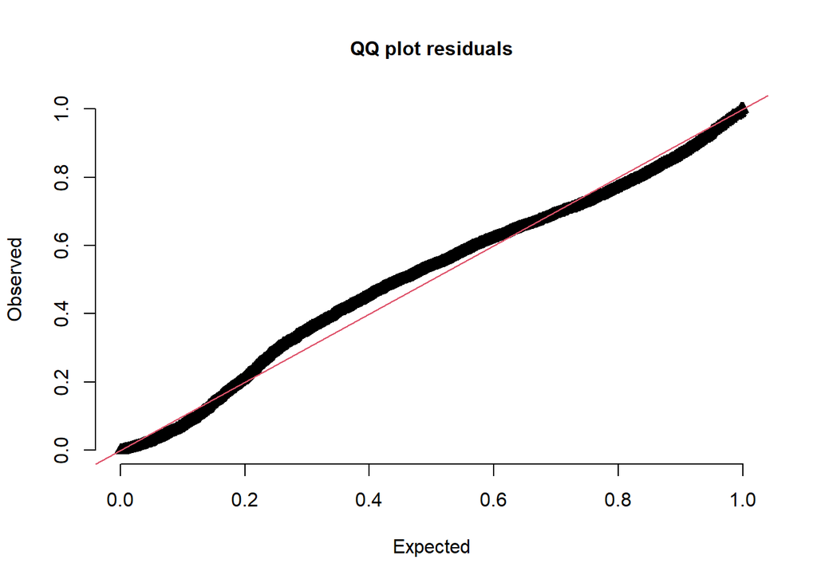

```r
model_nbinom_mixed_residuals %>%
  DHARMa::plotQQunif(FALSE, FALSE, FALSE)
```

The QQ plot compares the observed residuals to theoretically expected ones.

From an applied perspective this plot is not terrible, but it is certainly not ideal.

The deviance from the expected line may indicate model misspecification, but more likely missing variables.

## Residuals vs Predicted

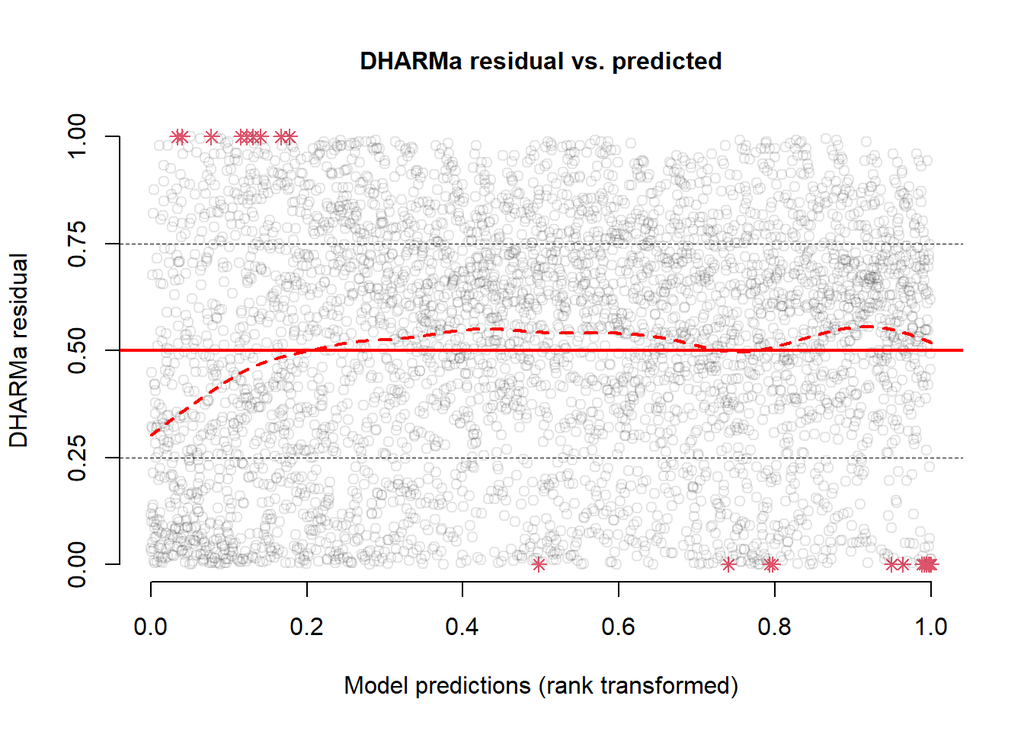

```r
model_nbinom_mixed_residuals %>%
  DHARMa::plotResiduals()
```

This residual plot can help identify problematic predictions. For the most part, the trend is within the inner quartile range.

However, a few outliers are noted which should be further investigated.

## Dispersion

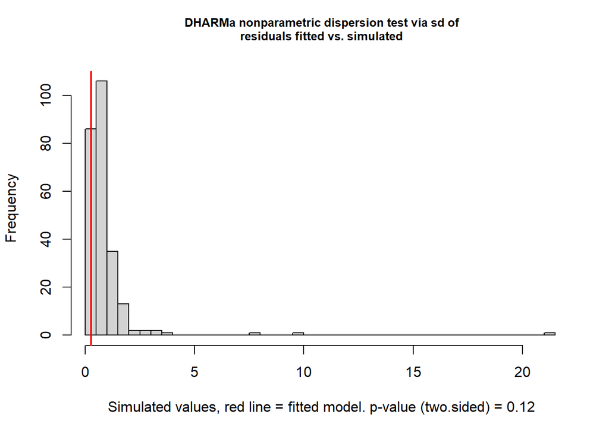

```
##
##  DHARMa nonparametric dispersion test via sd of residuals fitted vs.
##  simulated
##
## data:  simulationOutput
## dispersion = 0.29681, p-value = 0.12
## alternative hypothesis: two.sided
```

```r
model_nbinom_mixed_residuals %>%
  DHARMa::testDispersion()
```

## Zero Inflation

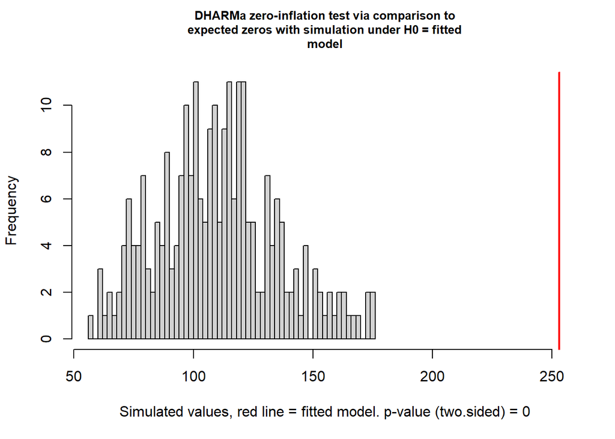

```
##
##  DHARMa zero-inflation test via comparison to expected zeros with
##  simulation under H0 = fitted model
##
## data:  simulationOutput
## ratioObsSim = 2.2883, p-value < 2.2e-16
## alternative hypothesis: two.sided
```

```r
model_nbinom_mixed_residuals %>%
  DHARMa::testZeroInflation()
```

This should be fixed. One solution might be to exclude the numerous parks from the data so that the model is not so biased to 0.

## QQ Plot of Random Effects

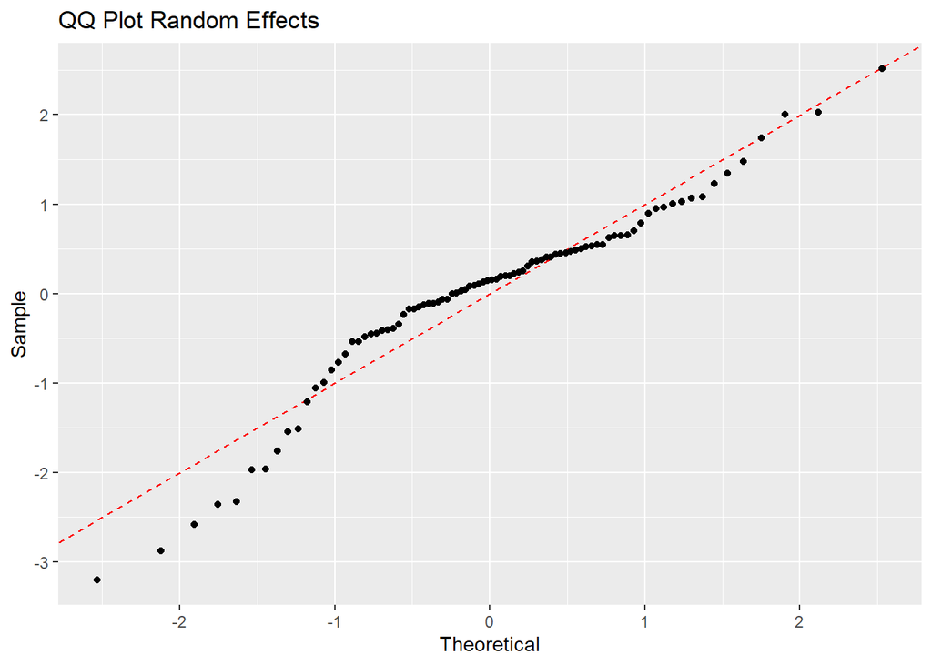

```r
(qq <- model_nbinom_mixed %>%
  glmmTMB::ranef() %>%
  { .$cond$neighborhood } %>%
  mutate(
    intercept = `(Intercept)`,
    neighborhood = rownames(.),
    theoretical = qqnorm(intercept, plot.it = FALSE)$x,
    sample = qqnorm(intercept, plot.it = FALSE)$y
  ) %>%
  ggplot(aes(x = theoretical, y = sample, label = neighborhood)) +
  geom_abline(intercept = 0, slope = 1, color = "red", linetype = "dashed") +
  geom_point() +
  labs(
    title = "QQ Plot Random Effects",
    x = "Theoretical",
    y = "Sample"
  )
)
```

Another assumption of the model is that the random effects are normally distributed. This can be examined with a QQ plot of the random effects.

Here we see some issues where some neighborhoods are under predicted while a few are over predicted.

This also warrants further investigation, but my initial reaction is that the parks are contributing to the under prediction.

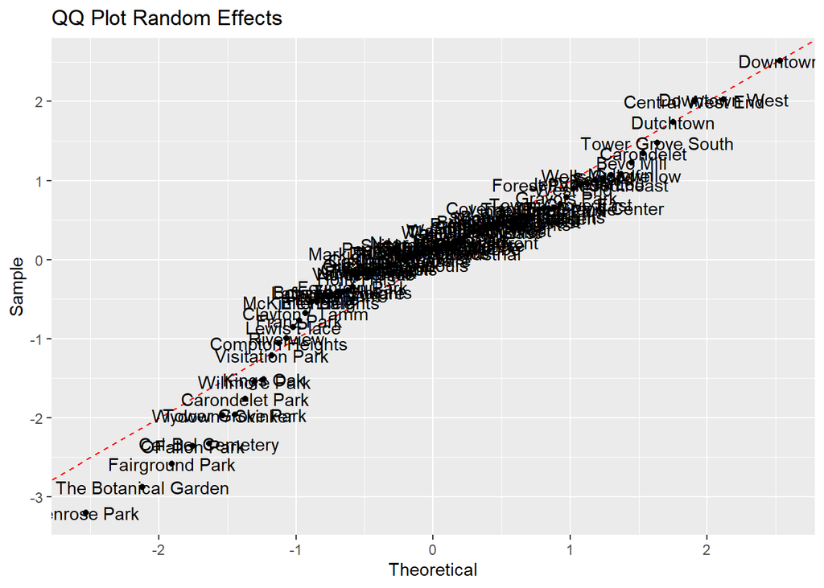

```r
qq + geom_text()
```

Adding the labels bears this thought out.

# Model Summary

## Log-Mean

```r
suppressWarnings(
  sjPlot::tab_model(
    model_nbinom_mixed,
    transform = NULL,
    show.intercept = FALSE,
    show.zeroinf = FALSE
  )
)
```

|  | offense count |  |  |
| --- | --- | --- | --- |
| Predictors | Log-Mean | CI | p |
| season [Autumn] | -0.10 | -0.15 – -0.05 | **<0.001** |
| season [Winter] | -0.18 | -0.22 – -0.13 | **<0.001** |
| season [Spring] | -0.08 | -0.13 – -0.03 | **0.001** |
| year | -0.12 | -0.14 – -0.09 | **<0.001** |
| type [C] | -1.42 | -1.47 – -1.37 | **<0.001** |
| type [M] | -0.73 | -0.78 – -0.68 | **<0.001** |
| type [F] | 0.70 | 0.65 – 0.74 | **<0.001** |
| log density | 0.14 | -0.21 – 0.50 | 0.427 |
| adi staternk | 0.07 | -0.02 – 0.16 | 0.155 |
| Random Effects |  |  |  |
| σ<sup>2</sup> | 0.23 |  |  |
| τ<sub>00</sub> <sub>neighborhood</sub> | 1.09 |  |  |
| ICC | 0.83 |  |  |
| N <sub>neighborhood</sub> | 88 |  |  |
| Observations | 4224 |  |  |
| Marginal R<sup>2</sup> / Conditional R<sup>2</sup> | 0.335 / 0.886 |  |  |

## Incident Rate Ratios

```r
suppressWarnings(
  sjPlot::tab_model(
    model_nbinom_mixed,
    transform = "exp",
    show.intercept = FALSE,
    show.zeroinf = FALSE
  )
)
```

|  | offense count |  |  |
| --- | --- | --- | --- |
| Predictors | Incidence Rate Ratios | CI | p |
| season [Autumn] | 0.90 | 0.86 – 0.95 | **<0.001** |
| season [Winter] | 0.84 | 0.80 – 0.88 | **<0.001** |
| season [Spring] | 0.92 | 0.88 – 0.97 | **0.001** |
| year | 0.89 | 0.87 – 0.91 | **<0.001** |
| type [C] | 0.24 | 0.23 – 0.25 | **<0.001** |
| type [M] | 0.48 | 0.46 – 0.51 | **<0.001** |
| type [F] | 2.00 | 1.92 – 2.10 | **<0.001** |
| log density | 1.15 | 0.81 – 1.65 | 0.427 |
| adi staternk | 1.07 | 0.98 – 1.17 | 0.155 |
| Random Effects |  |  |  |
| σ<sup>2</sup> | 0.23 |  |  |
| τ<sub>00</sub> <sub>neighborhood</sub> | 1.09 |  |  |
| ICC | 0.83 |  |  |
| N <sub>neighborhood</sub> | 88 |  |  |
| Observations | 4224 |  |  |
| Marginal R<sup>2</sup> / Conditional R<sup>2</sup> | 0.335 / 0.886 |  |  |

# Model Plots

## Effects

### Fixed Effects

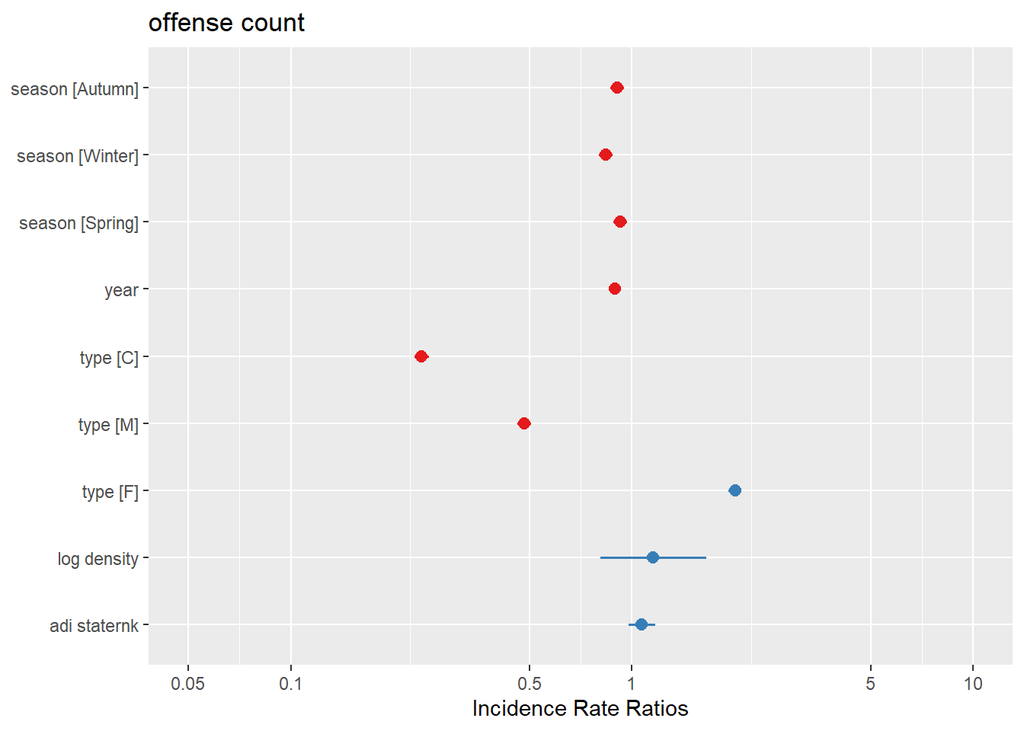

```r
# sjPlot needs to be updated to use a newer ggplot api
# suppress warning in mean time
suppressWarnings(
  model_nbinom_mixed %>%
    sjPlot::plot_model("est")
)
```

### Random Effects

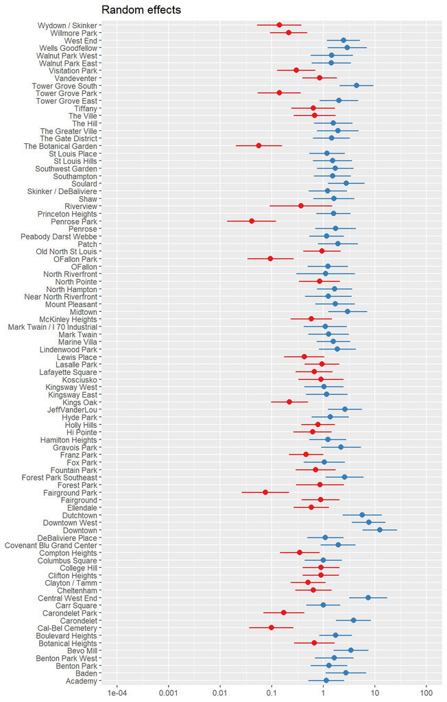

```r
model_nbinom_mixed %>%
  sjPlot::plot_model("re")
```

## Marginal Means

### Season

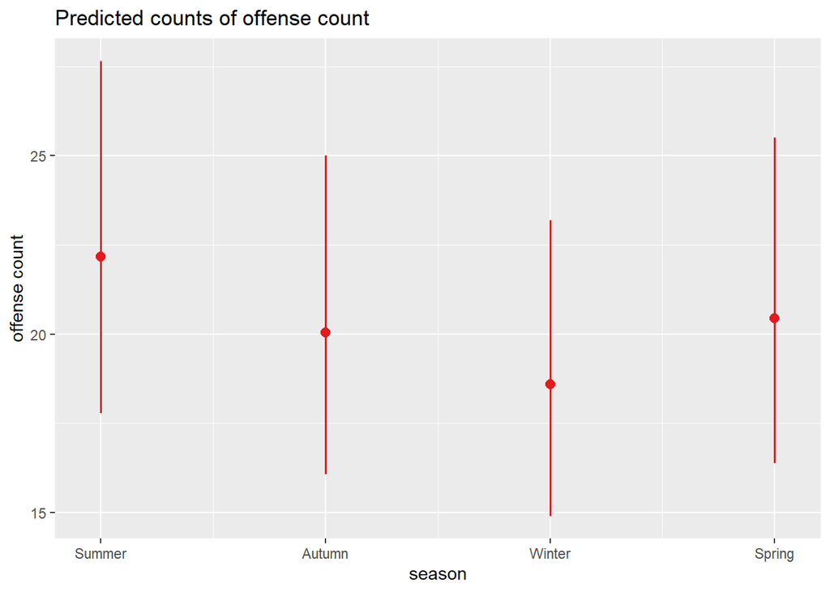

```r
model_nbinom_mixed %>%
  sjPlot::plot_model("emm", terms = "season")
```

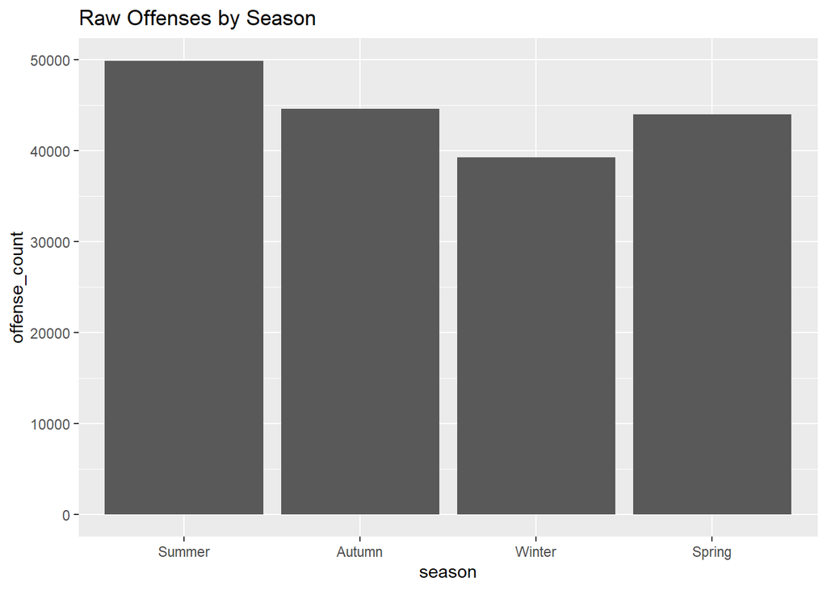

```r
crossed_data %>%
  group_by(season) %>%
  summarize(offense_count = sum(offense_count)) %>%
  ggplot(aes(season, offense_count)) +
  geom_col() +
  labs(title = "Raw Offenses by Season")
```

### Year

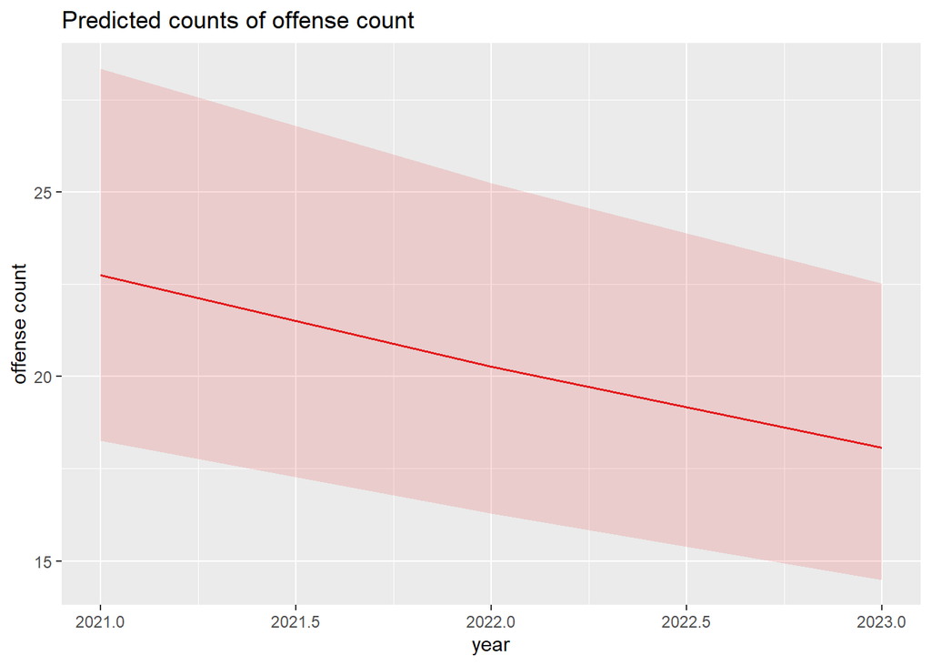

```r
model_nbinom_mixed %>%
  sjPlot::plot_model("emm", terms = "year")
```

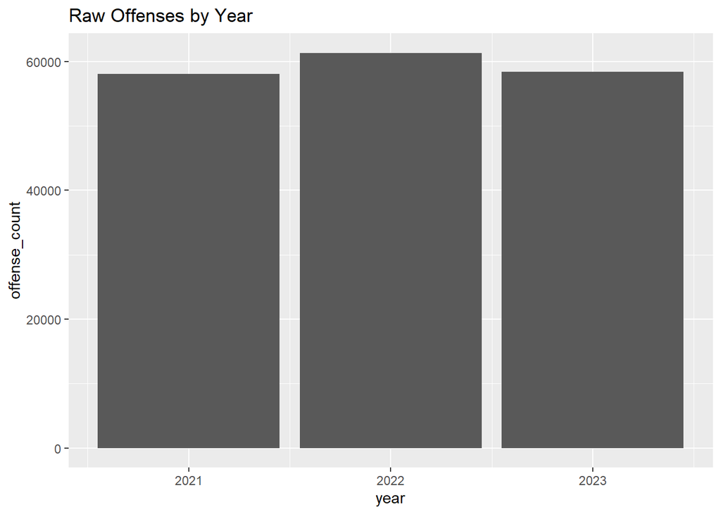

```r
crossed_data %>%
  group_by(year) %>%
  summarize(offense_count = sum(offense_count)) %>%
  ggplot(aes(year, offense_count)) +
  geom_col() +
  labs(title = "Raw Offenses by Year")
```

### Type

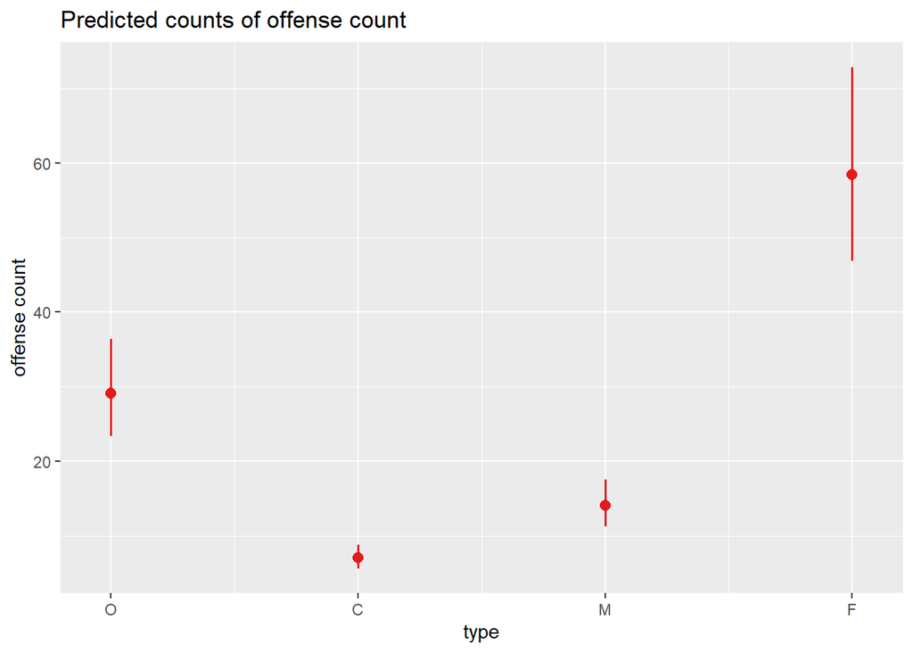

```r
model_nbinom_mixed %>%
  sjPlot::plot_model("emm", terms = "type")
```

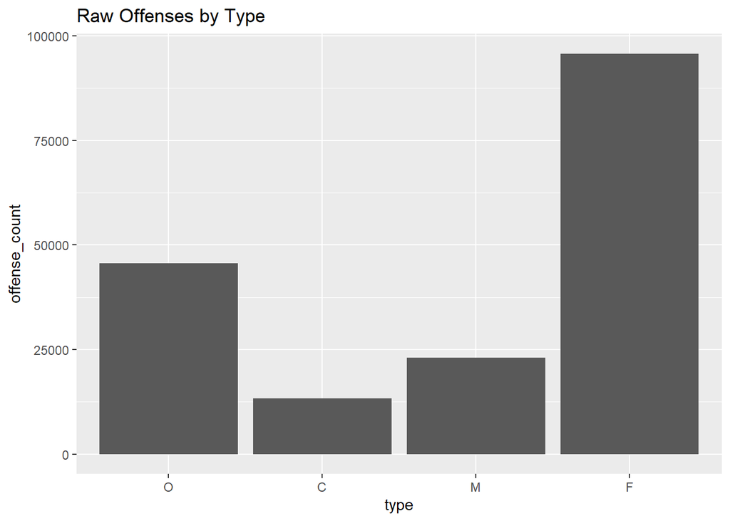

```r
crossed_data %>%
  group_by(type) %>%
  summarize(offense_count = sum(offense_count)) %>%
  ggplot(aes(type, offense_count)) +
  geom_col() +
  labs(title = "Raw Offenses by Type")
```

### Log Density

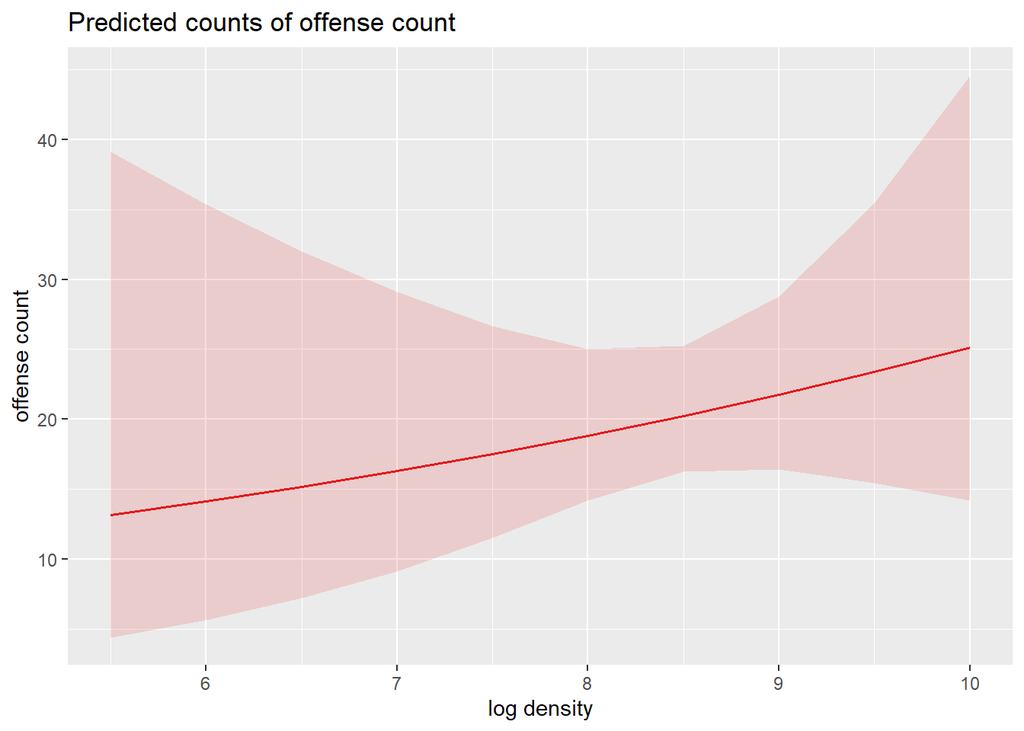

```r
model_nbinom_mixed %>%
  sjPlot::plot_model("emm", terms = "log_density")
```

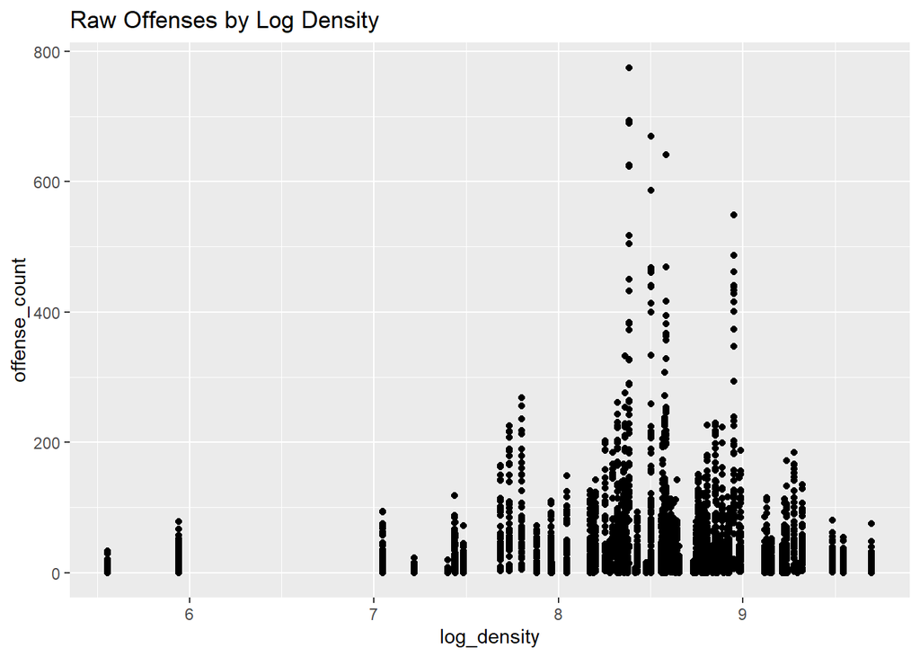

```r
crossed_data %>%
  ggplot(aes(log_density, offense_count)) +
  geom_point() +
  labs(title = "Raw Offenses by Log Density")
```

### ADI

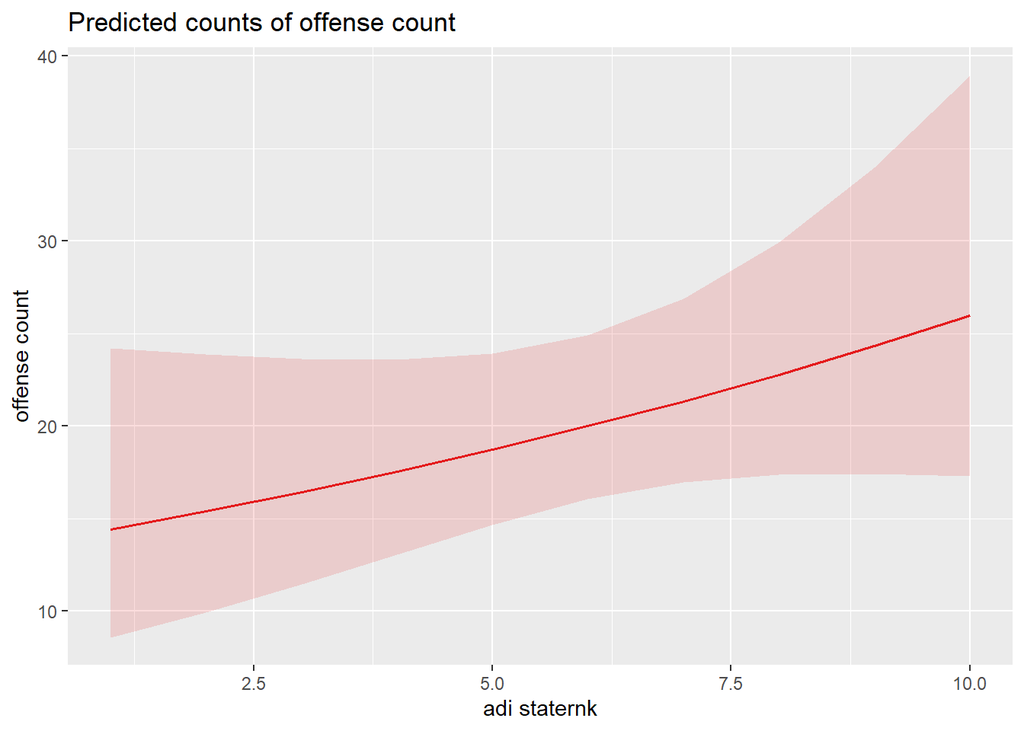

```r
model_nbinom_mixed %>%
  sjPlot::plot_model("emm", terms = "adi_staternk")
```

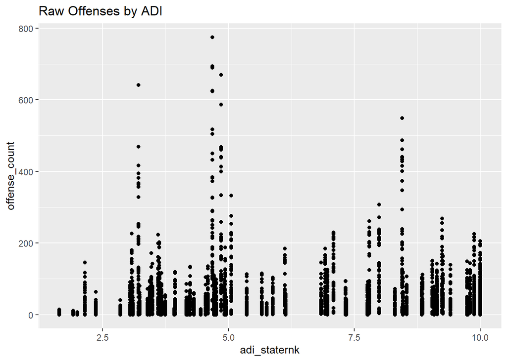

```r
crossed_data %>%
  ggplot(aes(adi_staternk, offense_count)) +
  geom_point() +
  labs(title = "Raw Offenses by ADI")
```

## Predictions

```r
pred_plots <- model_nbinom_mixed %>%
  sjPlot::plot_model("pred")
```

### Season

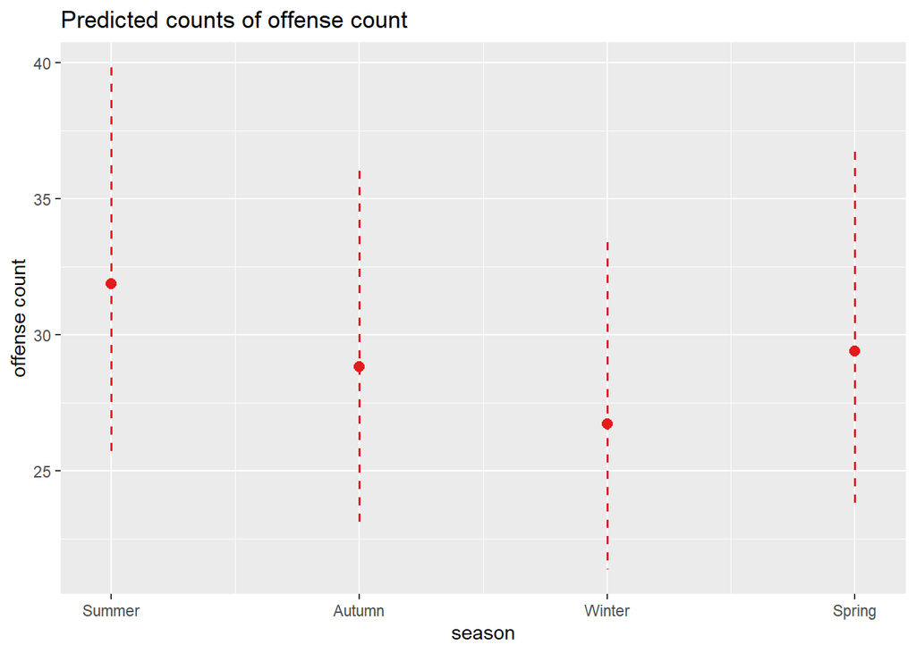

```r
pred_plots[1]
```

### Year

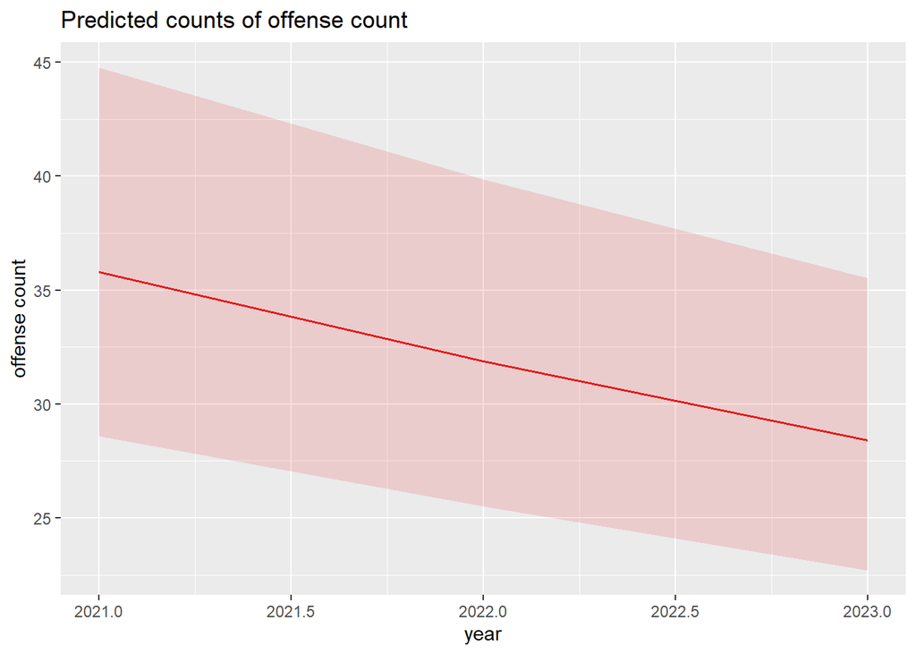

```r
pred_plots[2]
```

### Type

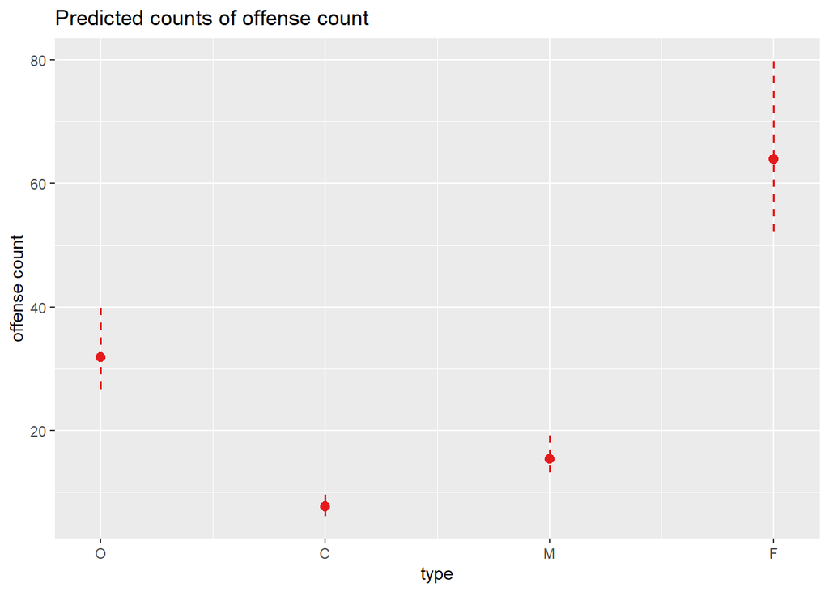

```r
pred_plots[3]
```

### Log Density

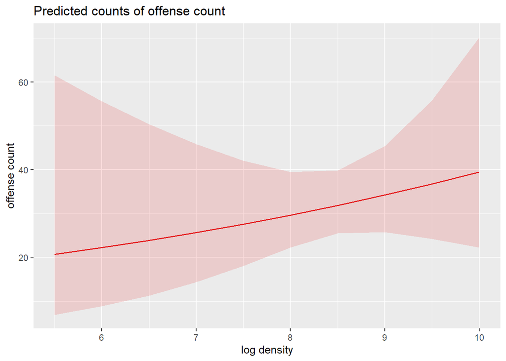

```r
pred_plots[4]
```

### ADI

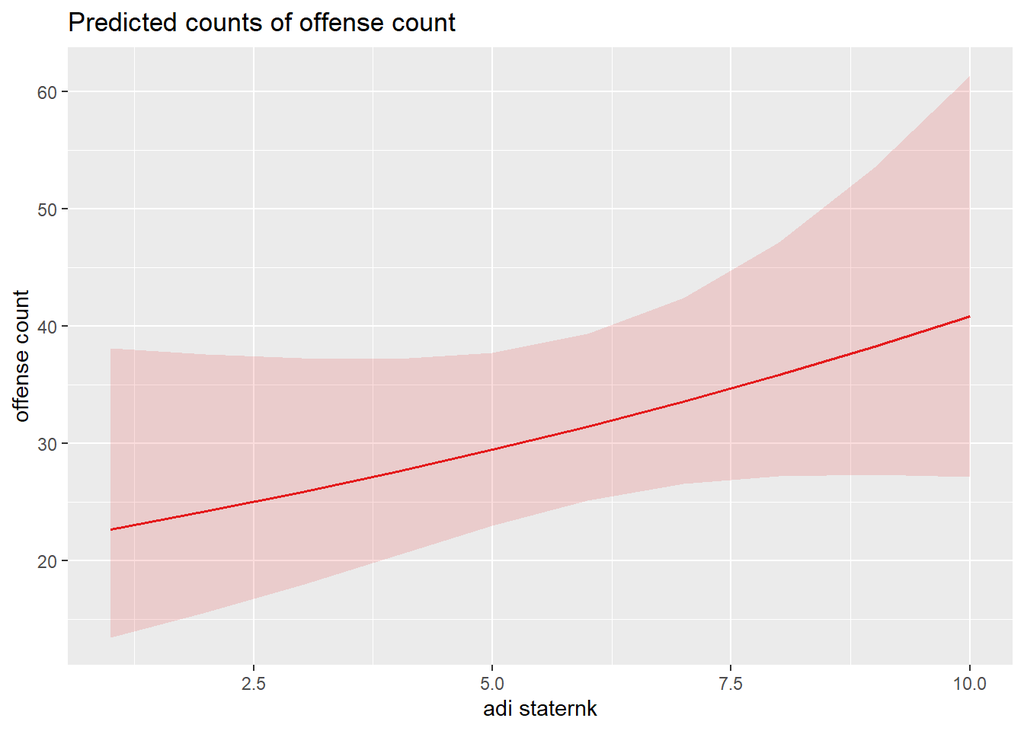

```r
pred_plots[5]
```

# Predictions

If the model fit was deemed acceptable, we could also make predictions based on the model.

Here are two examples:

## Low

```r
crossed_data %>%
  filter(
    neighborhood == "Cal-Bel Cemetery",
    season == "Autumn",
    year == 2022,
    type == "C"
  ) %>%
  gt()
```

| neighborhood | season | year | type | log_density | adi_staternk | offense_count |
| --- | --- | --- | --- | --- | --- | --- |
| Cal-Bel Cemetery | Autumn | 2022 | C | 7.398858 | 9.751434 | 0 |

```r
new_data <- tibble(
  neighborhood = "Cal-Bel Cemetery",
  season = factor("Autumn", levels = c("Summer", "Autumn", "Winter", "Spring")),
  year = 2022,
  type = factor("C", levels = c("O", "C", "M", "F")),
  log_density = 7.398858,
  adi_staternk = 9.751434
)
```

The predicted value is 0.73.

## High

```r
crossed_data %>%
  filter(
    neighborhood == "Downtown",
    season == "Summer",
    year == 2021,
    type == "F"
  )
```

```
## # A tibble: 1 × 7
##   neighborhood season  year type  log_density adi_staternk offense_count
##   <chr>        <fct>  <dbl> <fct>       <dbl>        <dbl>         <int>
## 1 Downtown     Summer  2021 F            8.38         4.68           775
```

```r
new_data <- tibble(
  neighborhood = "Downtown",
  season = factor("Summer", levels = c("Summer", "Autumn", "Winter", "Spring")),
  year = 2021,
  type = factor("F", levels = c("O", "C", "M", "F")),
  log_density = 8.384866,
  adi_staternk = 4.682408
)
```

The predicted value is 790.07.

# Discussion

The model does not provide an optimal fit and is relatively simplistic in its structure. Predictors are often time-invariant while the model considers a temporal dimension. Neighborhood area calculations do not account for uninhabitable area such as bodies of water which biases the population density calculations. Additionally, modeling at the offense level rather than the incident level may introduce biases, which could affect applications such as personnel assignment decisions.

Issues identified in the model diagnostics warrant further examination. Additional predictors, including new data sources, as well as feature engineering with existing variables, should be explored. Further modeling efforts are recommended. Ideally, a hierarchical model with offenses nested within incidents and incidents nested within neighborhoods would be preferable; however, this approach is not feasible due to the large number of incidents. An alternative would be to aggregate offenses to the incident level and model incidents nested within neighborhoods.